# Estudios de Informática, Multimedia y Telecomunicaciones

## 2.2 Preparación de los datos para el modelo

Para la futura evaluación del árbol de decisión, es necesario dividir el conjunto de datos en un conjunto de entrenamiento y un conjunto de prueba. El conjunto de entrenamiento es el subconjunto del conjunto original de datos utilizado para construir un primer modelo; y el conjunto de prueba, el subconjunto del conjunto original de datos utilizado para evaluar la calidad del modelo.

Lo más correcto será utilizar un conjunto de datos diferente del que utilizamos para construir el árbol, es decir, un conjunto diferente del de entrenamiento. No hay ninguna proporción fijada con respecto al número relativo de componentes de cada subconjunto, pero la más utilizada acostumbra a ser 2/3 para el conjunto de entrenamiento y 1/3, para el conjunto de prueba.

La variable por la que clasificaremos es el campo de si el pasajero sobrevivió o no, que está en la cuarta columna. De esta forma, tendremos un conjunto de datos para el entrenamiento y uno para la validación

```r
set.seed(666)
y <- data_random[,4]
X <- data_random[,1:3]
```

De forma dinámica podemos definir una forma de separar los datos en función de un parámetro, en este caso del “split_prop”. Definimos un parámetro que controla el split de forma dinámica en el test.

```r
split_prop <- 3
max_split<-floor(nrow(X)/split_prop)
tr_limit <- nrow(X)-max_split
ts_limit <- nrow(X)-max_split+1

trainX <- X[1:tr_limit,]
trainy <- y[1:tr_limit]
testX <- X[ts_limit+1:nrow(X),]
testy <- y[ts_limit+1:nrow(X)]
```

En la segunda opción podemos crear directamente un rango utilizando el mismo parámetro anterior.

```r
split_prop <- 3
indexes = sample(1:nrow(data), size=floor(((split_prop-1)/split_prop)*nrow(data)))
trainX<-X[indexes,]
trainy<-y[indexes]
testX<-X[-indexes,]
testy<-y[-indexes]
```

```r
summary(trainX);
```

```
##     CLASS               AGE                SEX
##  Length:1467        Length:1467        Length:1467
##  Class :character   Class :character   Class :character
##  Mode  :character   Mode  :character   Mode  :character
```

```r
summary(trainy)
```

```
##    Length     Class      Mode
##      1467 character character
```

```r
summary(testX)
```

```
##     CLASS               AGE                SEX
##  Length:734         Length:734         Length:734
##  Class :character   Class :character   Class :character
##  Mode  :character   Mode  :character   Mode  :character
```

```r
summary(testy)
```

```
##    Length     Class      Mode
##       734 character character
```

## 2.3 Creación del modelo, calidad del modelo y extracción de reglas

Se crea el árbol de decisión usando los datos de entrenamiento (no hay que olvidar que la variable outcome es de tipo factor):

```r
trainy = as.factor(trainy)
model <- C50::C5.0(trainX, trainy,rules=TRUE )
summary(model)
```

```
##
## Call:
## C5.0.default(x = trainX, y = trainy, rules = TRUE)
##
##
## C5.0 [Release 2.07 GPL Edition]      Tue May 11 19:02:42 2021
## -------------------------------
##
## Class specified by attribute `outcome'
##
## Read 1467 cases (4 attributes) from undefined.data
##
## Rules:
##
## Rule 1: (1169/255, lift 1.2)
##  SEX = Hombre
##  ->  class Muere  [0.781]
##
## Rule 2: (20, lift 2.9)
##  CLASS in {2a, 1a}
##  AGE = Menor
##  ->  class Sobrevive  [0.955]
##
## Rule 3: (298/75, lift 2.3)
##  SEX = Mujer
##  ->  class Sobrevive  [0.747]
##
## Default class: Muere
##
##
## Evaluation on training data (1467 cases):
##
##          Rules
##    ----------------
##      No      Errors
##
##       3  317(21.6%)   <<
##
##
##     (a)   (b)    <-classified as
##    ----  ----
##     914    75    (a): class Muere
##     242   236    (b): class Sobrevive
##
##
##  Attribute usage:
##
##  100.00% SEX
##    1.36% CLASS
##    1.36% AGE
##
##
## Time: 0.0 secs
```

Errors muestra el número y porcentaje de casos mal clasificados en el subconjunto de entrenamiento. El árbol obtenido clasifica erróneamente 317 de los 1467 casos dados, una tasa de error del 21.6%.

SEX = “Hombre” → Muere. Validez: 78,1%

CLASS “1ª”, “2ª” y AGE = “Menor” → Sobrevive. Validez: 95,5%

SEX = “Mujer” → Sobrevive. Validez: 74,7%

Por tanto, podemos concluir que el conocimiento extraído y cruzado con el análisis visual se resume en “las mujeres y los niños primero a excepción de que fueras de 3ª clase”.

A continuación, mostramos el árbol obtenido.

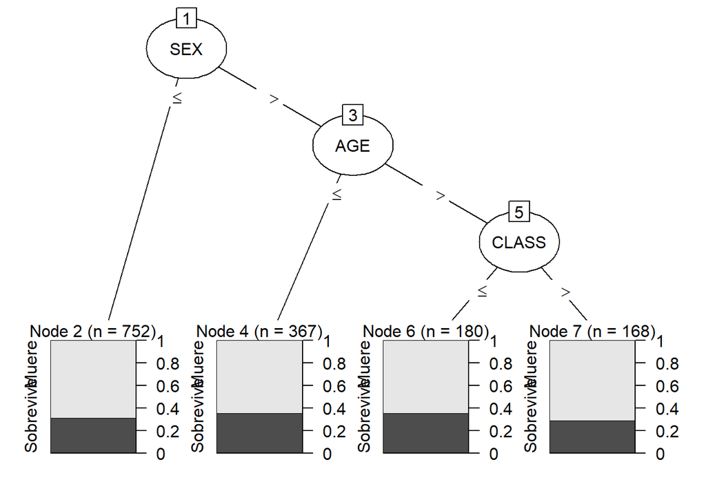

```r
model <- C50::C5.0(trainX, trainy)
plot(model)
```

## 2.4 Validación del modelo con los datos reservados

Una vez tenemos el modelo, podemos comprobar su calidad prediciendo la clase para los datos de prueba que nos hemos reservado al principio.

```r
predicted_model <- predict( model, testX, type="class" )
print(sprintf("La precisión del árbol es: %.4f %%",100*sum(predicted_model == testy) / length(predicted_model)))
```

```
## [1] "La precisión del árbol es: 78.2016 %"
```

Cuando hay pocas clases, la calidad de la predicción se puede analizar mediante una matriz de confusión que identifica los tipos de errores cometidos.

```r
mat_conf<-table(testy,Predicted=predicted_model)
mat_conf
```

```
##            Predicted
## testy       Muere Sobrevive
##   Muere       450        51
##   Sobrevive   109       124
```

Otra manera de calcular el porcentaje de registros correctamente clasificados usando la matriz de confusión:

```r
porcentaje_correct<-100 * sum(diag(mat_conf)) / sum(mat_conf)
print(sprintf("El %% de registros correctamente clasificados es: %.4f %%",porcentaje_correct))
```

```
## [1] "El % de registros correctamente clasificados es: 78.2016 %"
```

Además, tenemos a nuestra disposición el paquete gmodels para obtener información más completa:

```r
if(!require(gmodels)){
    install.packages('gmodels', repos='http://cran.us.r-project.org')
    library(gmodels)
}
CrossTable(testy, predicted_model,prop.chisq  = FALSE, prop.c = FALSE, prop.r =FALSE,dnn = c('Reality', 'Prediction'))
```

```
##
##
##    Cell Contents
## |-------------------------|
## |                       N |
## |         N / Table Total |
## |-------------------------|
##
##
## Total Observations in Table:  734
##
##
##              | Prediction
##      Reality |     Muere | Sobrevive | Row Total |
## -------------|-----------|-----------|-----------|
##        Muere |       450 |        51 |       501 |
##              |     0.613 |     0.069 |           |
## -------------|-----------|-----------|-----------|
##    Sobrevive |       109 |       124 |       233 |
##              |     0.149 |     0.169 |           |
## -------------|-----------|-----------|-----------|
## Column Total |       559 |       175 |       734 |
## -------------|-----------|-----------|-----------|
##
##
```

## 2.5 Prueba con una variación u otro enfoque algorítmico

En este apartado buscaremos probar con las variaciones que nos ofrece el paquete C5.0 para analizar cómo afectan a la creación de los árboles generados. Existen muchas posibles variaciones con otras funciones que podéis investigar. La idea es seguir con el enfoque de árboles de decisión explorando posibles opciones. Una vez tengamos un método alternativo, debemos analizar cómo se modifica el árbol y cómo afecta a la capacidad predictiva en el conjunto de test.

A continuación, utilizamos otro enfoque para comparar los resultados: incorpora como novedad “adaptative boosting”, basado en el trabajo Rob Schapire and Yoav Freund (1999). La idea de esta técnica es generar varios clasificadores, con sus correspondientes arboles de decisión y su ser de reglas. Cuando un nuevo caso va a ser clasificado, cada clasificador vota cual es la clase predicha. Los votos son sumados y determina la clase final.

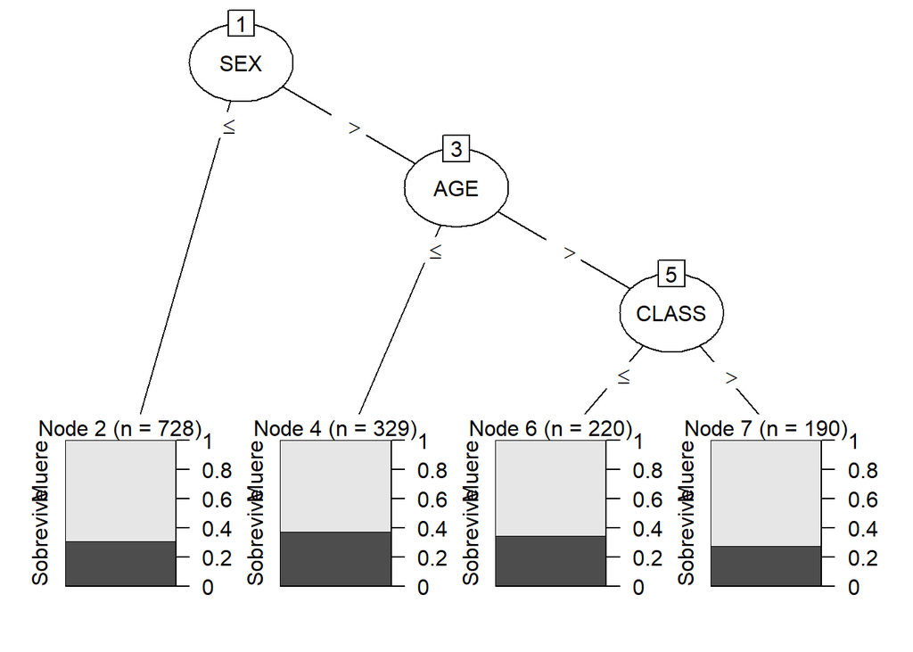

```r
modelo2 <- C50::C5.0(trainX, trainy, trials = 10)
plot(modelo2)
```

En este caso, dada la simplicidad del conjunto de ejemplo, no se aprecian diferencias, pero aparecerán en datos de mayor complejidad y modificando el parámetro “trials” se puede intentar mejorar los resultados.

Vemos a continuación cómo son las predicciones del nuevo árbol:

```r
predicted_model2 <- predict( modelo2, testX, type="class" )
print(sprintf("La precisión del árbol es: %.4f %%",100*sum(predicted_model2 == testy) / length(predicted_model2)))
```

```
## [1] "La precisión del árbol es: 79.5640 %"
```

Observamos como se modifica levemente la precisión del modelo a mejor.

```r
mat_conf<-table(testy,Predicted=predicted_model2)
mat_conf
```

```
##            Predicted
## testy       Muere Sobrevive
##   Muere       491        10
##   Sobrevive   140        93
```

Otra manera de calcular el porcentaje de registros correctamente clasificados usando la matriz de confusión:

```r
porcentaje_correct<-100 * sum(diag(mat_conf)) / sum(mat_conf)
print(sprintf("El %% de registros correctamente clasificados es: %.4f %%",porcentaje_correct))
```

```
## [1] "El % de registros correctamente clasificados es: 79.5640 %"
```

El algoritmo C5.0 incorpora algunas opciones para ver la importancia de las variables (ver documentación para los detalles entre los dos métodos):

```r
importancia_usage <- C50::C5imp(modelo2, metric = "usage")
importancia_splits <- C50::C5imp(modelo2, metric = "splits")
importancia_usage
```

```
##       Overall
## CLASS  100.00
## SEX    100.00
## AGE     91.55
```

```r
importancia_splits
```

```
##        Overall
## CLASS 36.84211
## SEX   36.84211
## AGE   26.31579
```

Curiosamente y aunque el conjunto de datos es muy sencillo, se aprecian diferencias en los métodos de importancia de las variables. Se recomienda en vuestro ejercicio mejorar la visualización de los resultados con la función ggplo2 o similar.

# 3 Solución del ejercicio

Los alumnos deben completar aquí los siguientes puntos que hacen referencia a los apartados de la rúbrica.

## 3.1 Estudio de los datos de entrada

Antes de comenzar con la práctica en sí, tenemos que hacer la lectura del fichero sobre el que vamos a hacer el estudio:

```r
df = read.csv(file = "./data/credit_kaggle.csv", header = TRUE, sep = ",", stringsAsFactors = TRUE)

# Creamos el dataframe de copia sobre el que vamos a trabajar
df_copy = df

head(df_copy)
```

```
##   checking_balance months_loan_duration credit_history   purpose amount
## 1           < 0 DM                    6       critical  radio/tv   1169
## 2       1 - 200 DM                   48         repaid  radio/tv   5951
## 3          unknown                   12       critical education   2096
## 4           < 0 DM                   42         repaid furniture   7882
## 5           < 0 DM                   24        delayed car (new)   4870
## 6          unknown                   36         repaid education   9055
##   savings_balance employment_length installment_rate personal_status
## 1         unknown           > 7 yrs                4     single male
## 2        < 100 DM         1 - 4 yrs                2          female
## 3        < 100 DM         4 - 7 yrs                2     single male
## 4        < 100 DM         4 - 7 yrs                2     single male
## 5        < 100 DM         1 - 4 yrs                3     single male
## 6         unknown         1 - 4 yrs                2     single male
##   other_debtors residence_history                 property age installment_plan
```

[output cut: 20 more lines]

A continuación observamos el número de registros y atributos que tiene nuestro dataset:

```r
str(df_copy)
```

```
## 'data.frame':    1000 obs. of  21 variables:
##  $ checking_balance    : Factor w/ 4 levels "< 0 DM","> 200 DM",..: 1 3 4 1 1 4 4 3 4 3 ...
##  $ months_loan_duration: int  6 48 12 42 24 36 24 36 12 30 ...
##  $ credit_history      : Factor w/ 5 levels "critical","delayed",..: 1 5 1 5 2 5 5 5 5 1 ...
##  $ purpose             : Factor w/ 10 levels "business","car (new)",..: 8 8 5 6 2 5 6 3 8 2 ...
##  $ amount              : int  1169 5951 2096 7882 4870 9055 2835 6948 3059 5234 ...
##  $ savings_balance     : Factor w/ 5 levels "< 100 DM","> 1000 DM",..: 5 1 1 1 1 5 4 1 2 1 ...
##  $ employment_length   : Factor w/ 5 levels "> 7 yrs","0 - 1 yrs",..: 1 3 4 4 3 3 1 3 4 5 ...
##  $ installment_rate    : int  4 2 2 2 3 2 3 2 2 4 ...
##  $ personal_status     : Factor w/ 4 levels "divorced male",..: 4 2 4 4 4 4 4 4 1 3 ...
##  $ other_debtors       : Factor w/ 3 levels "co-applicant",..: 3 3 3 2 3 3 3 3 3 3 ...
##  $ residence_history   : int  4 2 3 4 4 4 4 2 4 2 ...
##  $ property            : Factor w/ 4 levels "building society savings",..: 3 3 3 1 4 4 1 2 3 2 ...
##  $ age                 : int  67 22 49 45 53 35 53 35 61 28 ...
##  $ installment_plan    : Factor w/ 3 levels "bank","none",..: 2 2 2 2 2 2 2 2 2 2 ...
##  $ housing             : Factor w/ 3 levels "for free","own",..: 2 2 2 1 1 1 2 3 2 2 ...
##  $ existing_credits    : int  2 1 1 1 2 1 1 1 1 2 ...
##  $ default             : int  1 2 1 1 2 1 1 1 1 2 ...
##  $ dependents          : int  1 1 2 2 2 2 1 1 1 1 ...
##  $ telephone           : Factor w/ 2 levels "none","yes": 2 1 1 1 1 2 1 2 1 1 ...
##  $ foreign_worker      : Factor w/ 2 levels "no","yes": 2 2 2 2 2 2 2 2 2 2 ...
##  $ job                 : Factor w/ 4 levels "mangement self-employed",..: 2 2 4 2 2 4 2 1 4 1 ...
```

Observamos que tenemos 1000 observaciones y 21 variables, dentro de estas variables pueden ser de dos tipos o categóricas o numéricas.

Puesto que no viene por internet nada de información sobre este dataset de lo que significa cada variable y los valores que pueden tomar y qué significan estos, hemos decidido seleccionar aquellas que realmente sabemos su significado y que a priori son interestantes para ver si el conceder un préstamo a una persona genera un riesgo a la entidad bancaria o no.

Aunque más adelante analizaremos las correlaciones del dataset, vamos a ver tres posibles variables numéricas que podemos eliminar si no están correlacionadas con default:

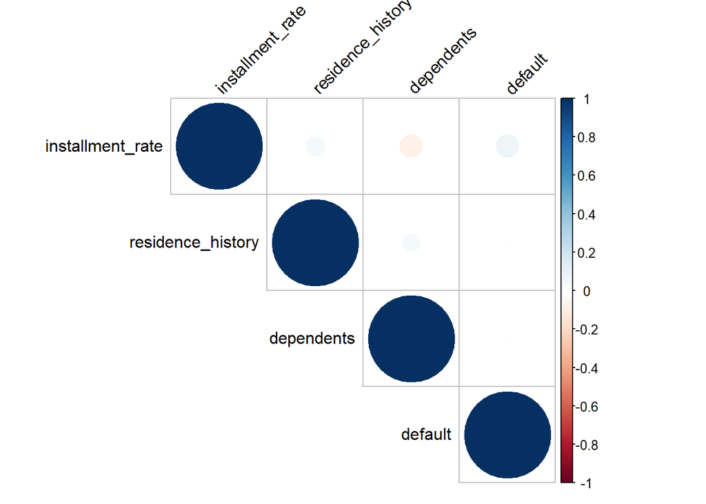

```r
library(corrplot)
corrplot(cor(df_copy[, c("installment_rate", "residence_history", "dependents", "default")]), type = "upper",
         order = "original",
         tl.col = "black",
         tl.srt = 45)
```

De la anterior ejecución observamos, que dichas variables no están correlacionadas entre sí ni con default, por lo que procedemos a eliminar estas variables del dataset ya que no nos aportan mucha información.

Por otro lado, la variable installment numérica y su variable categórica a parte de que no sabemos realmente lo que significan hemos visto que no aportan mucha información por lo que las vamos a eliminar también. Además, la variable proporty tampoco nos proporciona mucha información respecto al análisis que vamos a realizar, es decir, el saber si la propiedad es desconocida, o del estado no nos aporta mucha información, ya que housing nos está indicando si el cliente tiene propiedad o no y de qué tipo.

Por lo tanto, una vez hecho este pequeño análisis seleccionamos las variables más interesantes, las cuales son las siguientes:

```r
columns = c("checking_balance", "months_loan_duration", "credit_history", "purpose", "amount", "savings_balance", "employment_length", "personal_status", "age", "housing", "existing_credits", "foreign_worker", "job", "default")

df_copy = df_copy[, columns]

str(df_copy)
```

```
## 'data.frame':    1000 obs. of  14 variables:
##  $ checking_balance    : Factor w/ 4 levels "< 0 DM","> 200 DM",..: 1 3 4 1 1 4 4 3 4 3 ...
##  $ months_loan_duration: int  6 48 12 42 24 36 24 36 12 30 ...
##  $ credit_history      : Factor w/ 5 levels "critical","delayed",..: 1 5 1 5 2 5 5 5 5 1 ...
##  $ purpose             : Factor w/ 10 levels "business","car (new)",..: 8 8 5 6 2 5 6 3 8 2 ...
##  $ amount              : int  1169 5951 2096 7882 4870 9055 2835 6948 3059 5234 ...
##  $ savings_balance     : Factor w/ 5 levels "< 100 DM","> 1000 DM",..: 5 1 1 1 1 5 4 1 2 1 ...
##  $ employment_length   : Factor w/ 5 levels "> 7 yrs","0 - 1 yrs",..: 1 3 4 4 3 3 1 3 4 5 ...
##  $ personal_status     : Factor w/ 4 levels "divorced male",..: 4 2 4 4 4 4 4 4 1 3 ...
##  $ age                 : int  67 22 49 45 53 35 53 35 61 28 ...
##  $ housing             : Factor w/ 3 levels "for free","own",..: 2 2 2 1 1 1 2 3 2 2 ...
##  $ existing_credits    : int  2 1 1 1 2 1 1 1 1 2 ...
##  $ foreign_worker      : Factor w/ 2 levels "no","yes": 2 2 2 2 2 2 2 2 2 2 ...
##  $ job                 : Factor w/ 4 levels "mangement self-employed",..: 2 2 4 2 2 4 2 1 4 1 ...
##  $ default             : int  1 2 1 1 2 1 1 1 1 2 ...
```

Ahora vemos que hemos reducido la dimensionalidad del dataset de 21 variables a 14, pero seguimos manteniendo el mismo número de registros.

El significado de las variables que hemos seleccionado es el siguiente:

**checking_balance** Factor - Balance de gastos, desconocemos el significado de DM.

**months_loan_duration** Integer - Duración del préstamos en meses.

**credit_history** Factor - Estado del préstamo, si es crítico, está completamente pagado, una parte pagada…

**purpose** Factor - Propósito del préstamo.

**amount** Integer - Cantidad del préstamo.

**savings_balance** Factor - Balance de ahorros, desconocemos el significado de DM.

**employment_length** Factor - Años que lleva en el empleo el cliente.

**personal_status** Factor - Estado civil.

**age** Integer - Edad del cliente.

**housing** Factor - Tipo de vivienda.

**existing_credits** Integer - Número de créditos del cliente.

**foreign_worker** Factor - Trabajor extranjero.

**job** Factor - Tipo de trabajo del cliente.

**default** Integer - Variable objetivo, nos indica si el préstamo no es de riesgo 1, o si es de riesgo 2.

Una vez que tenemos clara la información que compone al dataset, vamos a realizar un pequeño análisis de sus datos:

```r
summary(df_copy)
```

```
##    checking_balance months_loan_duration                credit_history
##  < 0 DM    :274     Min.   : 4.0         critical              :293
##  > 200 DM  : 63     1st Qu.:12.0         delayed               : 88
##  1 - 200 DM:269     Median :18.0         fully repaid          : 40
##  unknown   :394     Mean   :20.9         fully repaid this bank: 49
##                     3rd Qu.:24.0         repaid                :530
##                     Max.   :72.0
##
##        purpose        amount           savings_balance  employment_length
##  radio/tv  :280   Min.   :  250   < 100 DM     :603    > 7 yrs   :253
##  car (new) :234   1st Qu.: 1366   > 1000 DM    : 48    0 - 1 yrs :172
##  furniture :181   Median : 2320   101 - 500 DM :103    1 - 4 yrs :339
##  car (used):103   Mean   : 3271   501 - 1000 DM: 63    4 - 7 yrs :174
##  business  : 97   3rd Qu.: 3972   unknown      :183    unemployed: 62
##  education : 50   Max.   :18424
##  (Other)   : 55
##       personal_status      age            housing    existing_credits
##  divorced male: 50    Min.   :19.00   for free:108   Min.   :1.000
##  female       :310    1st Qu.:27.00   own     :713   1st Qu.:1.000
##  married male : 92    Median :33.00   rent    :179   Median :1.000
##  single male  :548    Mean   :35.55                  Mean   :1.407
##                       3rd Qu.:42.00                  3rd Qu.:2.000
##                       Max.   :75.00                  Max.   :4.000
##
##  foreign_worker                      job         default
##  no : 37        mangement self-employed:148   Min.   :1.0
##  yes:963        skilled employee       :630   1st Qu.:1.0
##                 unemployed non-resident: 22   Median :1.0
##                 unskilled resident     :200   Mean   :1.3
##                                               3rd Qu.:2.0
##                                               Max.   :2.0
##
```

Para finalizar con este apartado antes de realizar el siguiente, vamos a ver si tenemos datos perdidos, es decir, registros que no contegan datos:

```r
colSums(is.na(df_copy))
```

```
##     checking_balance months_loan_duration       credit_history
##                    0                    0                    0
##              purpose               amount      savings_balance
##                    0                    0                    0
##    employment_length      personal_status                  age
##                    0                    0                    0
##              housing     existing_credits       foreign_worker
##                    0                    0                    0
##                  job              default
##                    0                    0
```

Tal y como podemos ver no tenenemos valores perdidos, lo que significa que todos los datos están completos y podemos pasar a realizar el análisis descriptivo y de correlaciones.

## 3.2 Análisis descriptivo y de correlaciones

Una vez que hemos hecho un pequeño análisis sobre los datos que tenemos con el fin de saber qué campos hay, cuales son sus valores, si hay valores perdidos… Lo siguiente es hacer un análisis en profundiad de los mismos.

En este apartado lo vamos a dividir en tres puntos: el análisis de las distribuciones de cada variable, el cómo afecta cada variable respecto al riesgo de conceder un préstamo, y por último las correlaciones entre las variables numéricas.

### 3.2.1 Distribuciones

Lo primero que debemos de hacer es analizar las distribuciones de cada variable, para saber si sigue una distribución normal, si hay valores atípicos…

La primera variable a analizar es checking_balance o el balance de gastos:

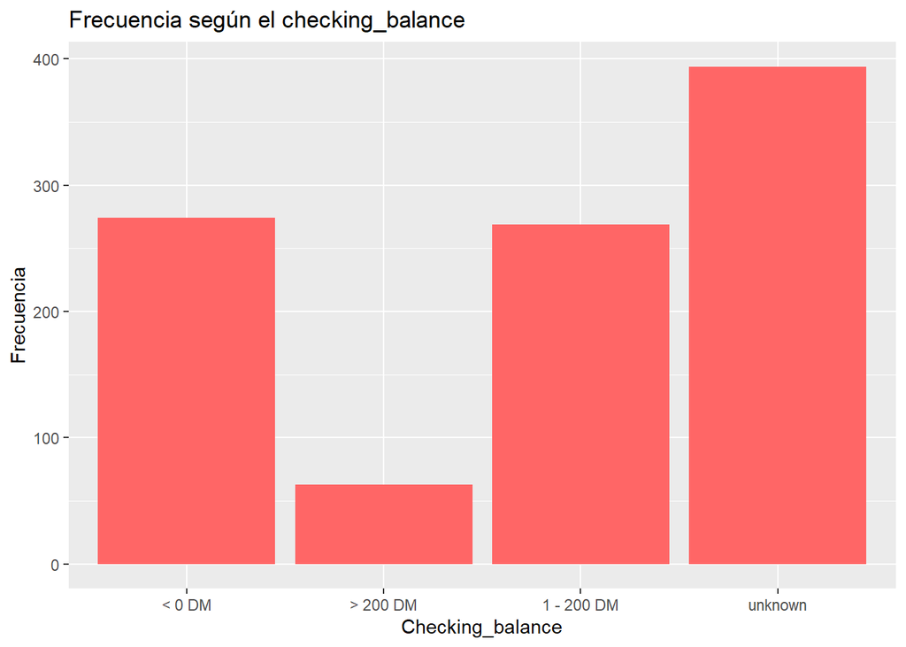

```r
library (ggplot2)

ggplot(data=df_copy,aes(x=checking_balance)) +
  geom_bar(fill = "#FF6666") +
  ylab("Frecuencia") +
  xlab("Checking_balance") +
  ggtitle("Frecuencia según el checking_balance")
```

Observamos que la gran mayoría de balances de gastos con la excepción de los desconocidos, o el balance es < 0 DM o está entre 1 y 200 DM. Cabe destacar que los valores desconocidos podríamos sustituirlos por los más frecuentes o usar otra medida, pero si hacemos eso vamos a sesgar la información real que tenemos del dastaset, es por ello que hemos decidido mantener dicho nivel.

La siguiente variable a analizar es months_loan_duration:

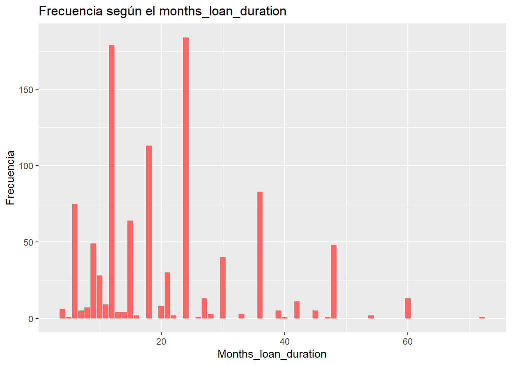

```r
ggplot(data=df_copy,aes(x=months_loan_duration)) +
  geom_bar(fill = "#FF6666") +
  ylab("Frecuencia") +
  xlab("Months_loan_duration") +
  ggtitle("Frecuencia según el months_loan_duration")
```

La siguiente variable a analizar es credit_history:

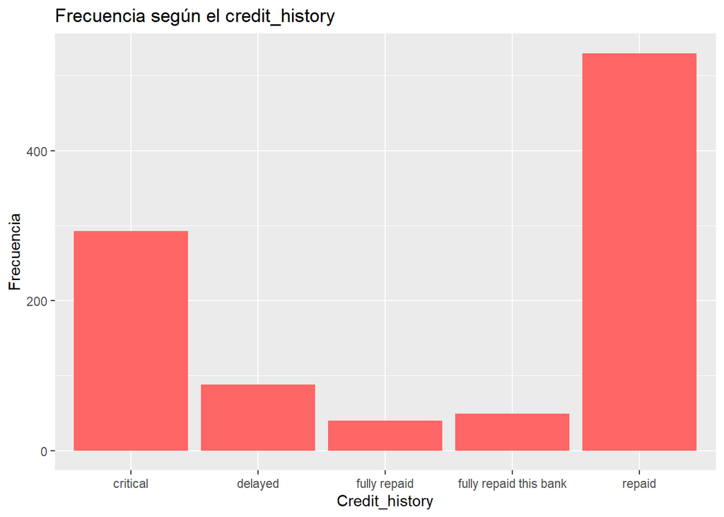

```r
ggplot(data=df_copy,aes(x=credit_history)) +
  geom_bar(fill = "#FF6666") +
  ylab("Frecuencia") +
  xlab("Credit_history") +
  ggtitle("Frecuencia según el credit_history")
```

Esta variable es curiosa ya que vemos que la gran mayoría de casos son préstamos repagados, es decir, que no se han terminado de pagar pero se sigue cumpliendo con los pagos, por otro lado, vemos que no hay muchos préstamos retrasados pero sí críticos, por lo que es interesante analizar que en esta entidad bancaria algo menos de un tercio de los datos son préstamos críticos.

Continuamos analizando la distribución de la variable purpose:

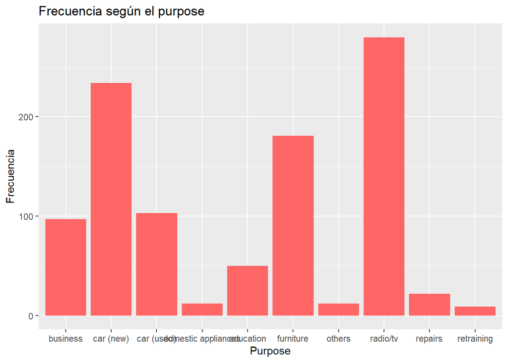

```r
ggplot(data=df_copy,aes(x=purpose)) +
  geom_bar(fill = "#FF6666") +
  ylab("Frecuencia") +
  xlab("Purpose") +
  ggtitle("Frecuencia según el purpose")
```

La siguiente variable a analizar es amount o la cantidad del préstamo:

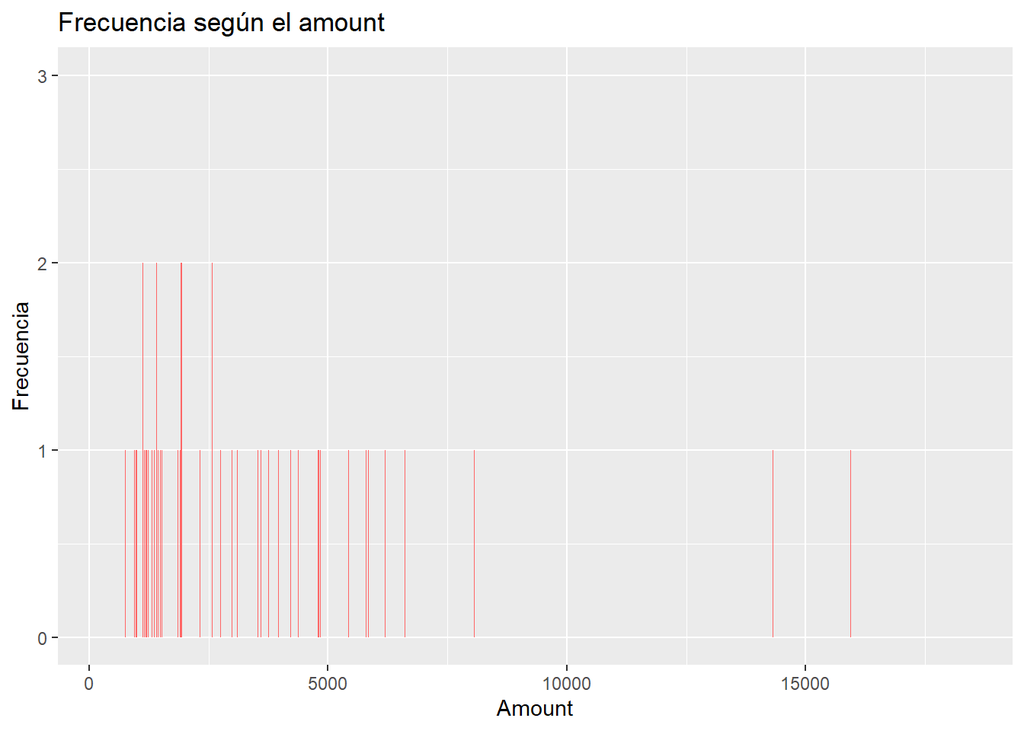

```r
ggplot(data=df_copy,aes(x=amount)) +
  geom_bar(fill = "#FF6666") +
  ylab("Frecuencia") +
  xlab("Amount") +
  ggtitle("Frecuencia según el amount")
```

Aunque la anterior gráfica no la hemos discretizado, es decir, podríamos crear diferentes categorías para ver mejor el gráfico, mantenemos esta gráfica ya que queda muy claro a nivel visual que prácticamente la mayoría de las cantidades para un préstamo se mueven en el intervalo 250 dólares a 5000 dólares, es decir, la cantidad que se suele conceder en este banco es baja, ya sea por el uso que se va a dar al préstamo, porque esta entidad tiene criterios más exigentes… Aún así vemos uqe no sigue una distribución normal, además no podemos considerar que las cantidades grandes sean anómalas, ya que éstas pueden ser totalmente lícitas.

La siguiente variable a analizar es savings_balance o el balance de los ahorros:

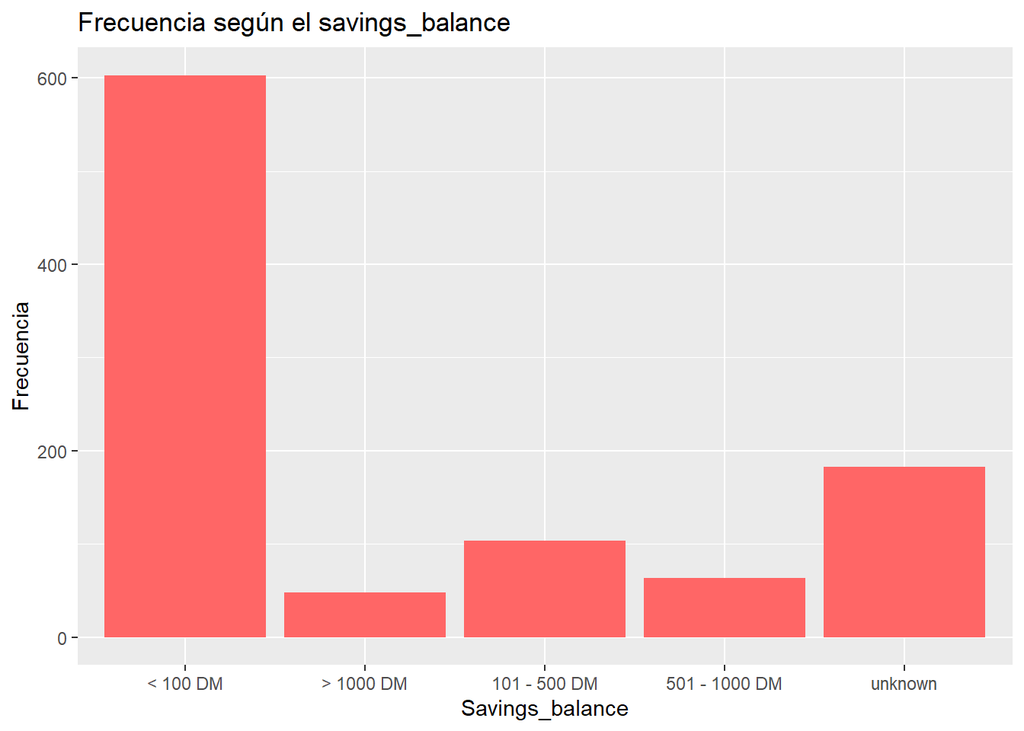

```r
ggplot(data=df_copy,aes(x=savings_balance)) +
  geom_bar(fill = "#FF6666") +
  ylab("Frecuencia") +
  xlab("Savings_balance") +
  ggtitle("Frecuencia según el savings_balance")
```

Del anterior gráfico observamos que la gran mayoría de los clientes tienen un balance de ahorros bajo, además aunque el porcentaje de desconocidos no sea muy elevado sigue siendo significante respecto a los otros balances.

También podemos analizar los años trabajados por cada cliente:

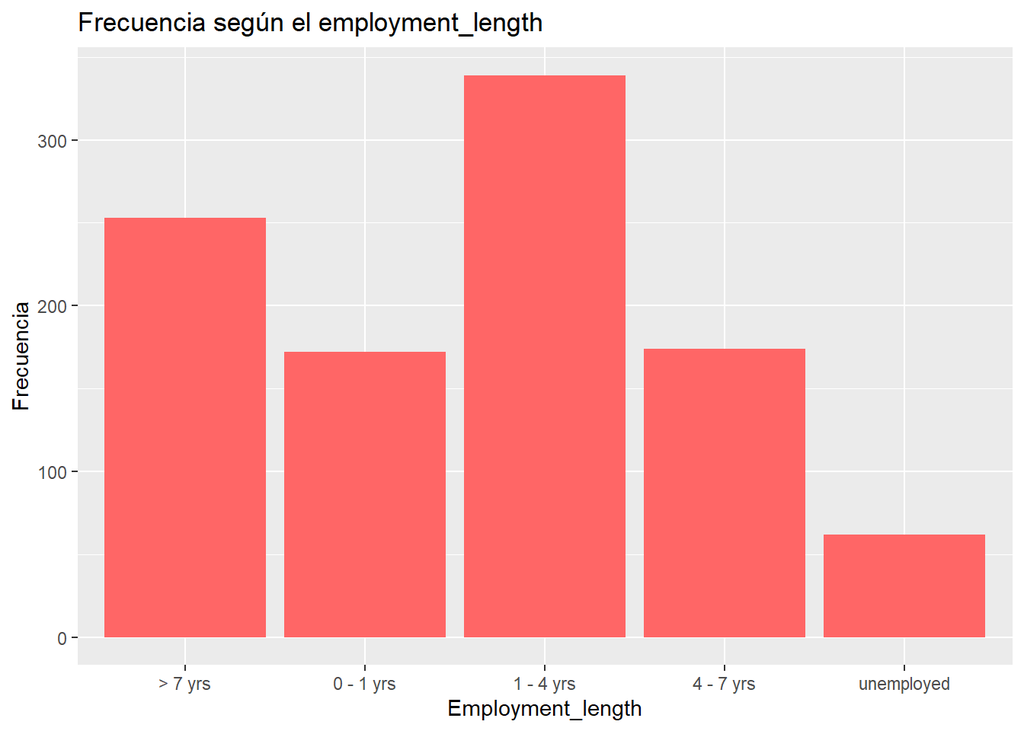

```r
ggplot(data=df_copy,aes(x=employment_length)) +
  geom_bar(fill = "#FF6666") +
  ylab("Frecuencia") +
  xlab("Employment_length") +
  ggtitle("Frecuencia según el employment_length")
```

La siguiente variable a analizar es personal_status:

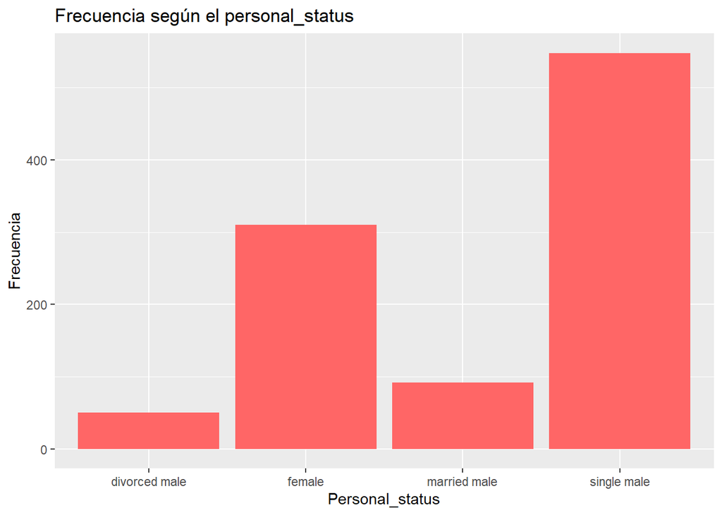

```r
ggplot(data=df_copy,aes(x=personal_status)) +
  geom_bar(fill = "#FF6666") +
  ylab("Frecuencia") +
  xlab("Personal_status") +
  ggtitle("Frecuencia según el personal_status")
```

Es curioso ver que la gran mayoría de veces que se pide un préstamo es por un hombrem y éste suele estar soltero. Respecto a las mujeres, el dataset no determina si el nivel female hace referencia a todas las mujeres (divorciadas, casadas o solteras) pero vamos a considerar que es así, que dicho nivel representa todos los casos al igual que en los hombres.

En cuanto a la variable age:

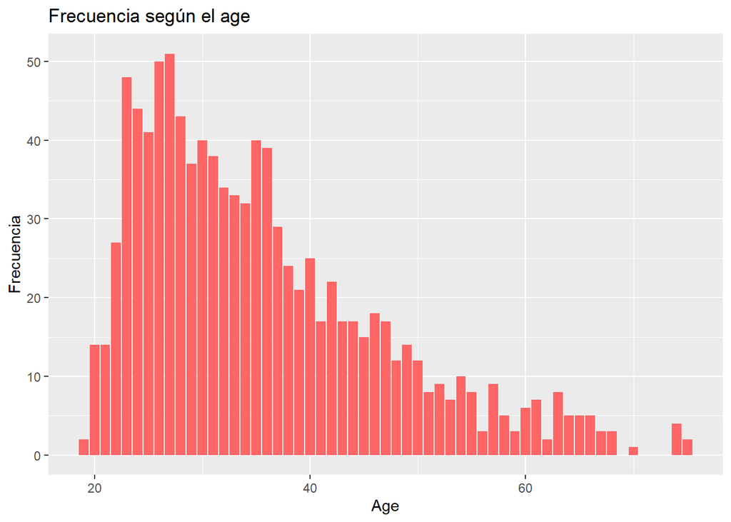

```r
ggplot(data=df_copy,aes(x=age)) +
  geom_bar(fill = "#FF6666") +
  ylab("Frecuencia") +
  xlab("Age") +
  ggtitle("Frecuencia según el age")
```

Vemos que no sigue una distribución normal, sin embargo, la gran mayoría de gente que pide un préstamo se encuentra entre los 25 a los 35, esto tiene toda la lógica del mundo ya que es aquí donde uno se independiza, se compra su coche, su casa…

Podemos analizar también la variable housing:

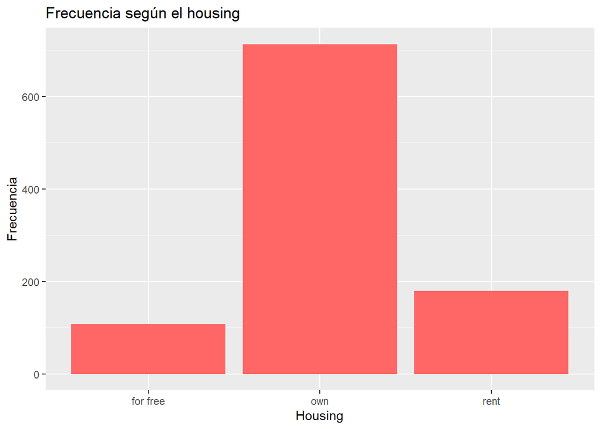

```r
ggplot(data=df_copy,aes(x=housing)) +
  geom_bar(fill = "#FF6666") +
  ylab("Frecuencia") +
  xlab("Housing") +
  ggtitle("Frecuencia según el housing")
```

Este gráfico es significate, ya que vemos que en la gran mayoría de los casos los cliente tienen su propia casa, es decir, no viven ni de alquier ni en viviendas del estado.

Podemos analizar también los créditos que tiene cada cliente:

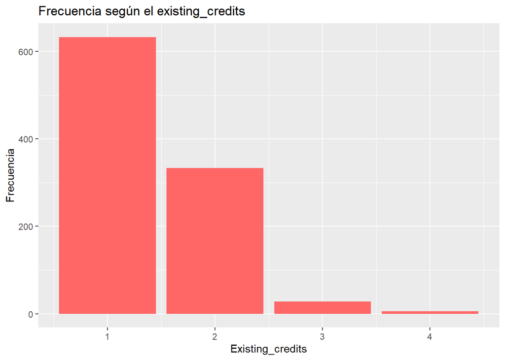

```r
ggplot(data=df_copy,aes(x=existing_credits)) +
  geom_bar(fill = "#FF6666") +
  ylab("Frecuencia") +
  xlab("Existing_credits") +
  ggtitle("Frecuencia según el existing_credits")
```

Vemos que por norma general los clientes tienen uno o como mucho dos créditos, ya que hay muy poca gente con 3 y 4 créditos al mismo tiempo.

Podemos analizar si el tipo de cliente que solicita el préstamo es extranjero o no:

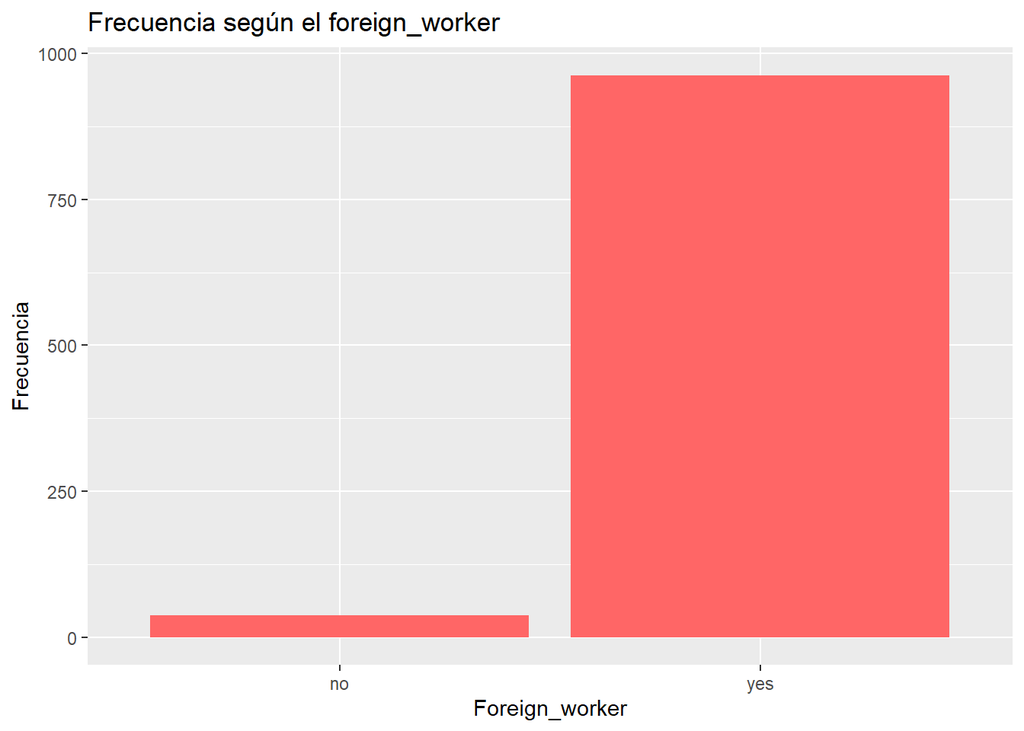

```r
ggplot(data=df_copy,aes(x=foreign_worker)) +
  geom_bar(fill = "#FF6666") +
  ylab("Frecuencia") +
  xlab("Foreign_worker") +
  ggtitle("Frecuencia según el foreign_worker")
```

Y vemos que sí, que esta entidad bancaria tiene un público mayor sobre trabajadores extranjeros, realmente casi todos son inmigrantes.

También podemos analizar qué tipo de trabajo tienen los clientes:

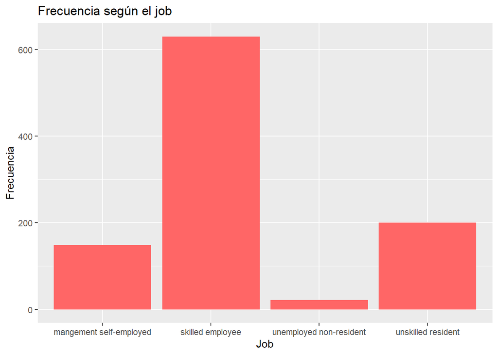

```r
ggplot(data=df_copy,aes(x=job)) +
  geom_bar(fill = "#FF6666") +
  ylab("Frecuencia") +
  xlab("Job") +
  ggtitle("Frecuencia según el job")
```

Vemos que la gran mayoría está especializada en su trabajo y que hay muy pocos autónomos. Además, apenas existe el cliente que no sea residente en el país y esté desempleado.

Finalmente, vamos a analizar la variable objetivo default, ésta nos indica el riesgo al conceder un préstamo o no, siendo 1 que no hay riesgo y 2 todo lo contrario:

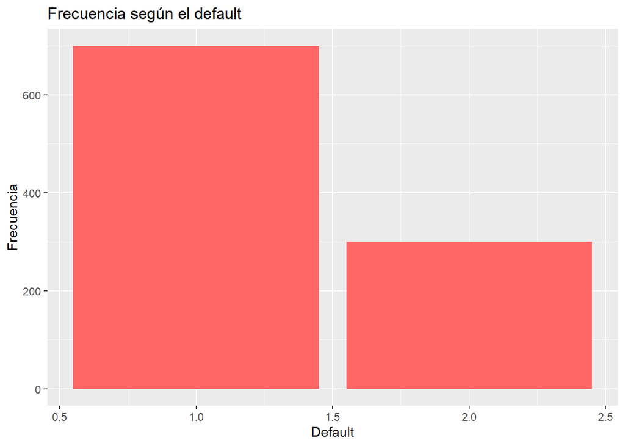

```r
ggplot(data=df_copy,aes(x=default)) +
  geom_bar(fill = "#FF6666") +
  ylab("Frecuencia") +
  xlab("Default") +
  ggtitle("Frecuencia según el default")
```

Tal y como podemos ver la gran mayoría de casos son préstamos que no hay riesgo, es decir, dos tercios de los datos son datos en lo que no tenemos riesgo al conceder el préstamo, sin embargo, hay un tercio en el que sí, por lo tanto vamos a analizar cuán de probable es que un préstamo sea de riesgo dependiendo de cada una de las variables independientes.

### 3.2.2 Análisis del riesgo del préstamo respecto a las variables independientes

En este apartado vamos a realizar el estudio del riesgo de conceder un préstamo según cada una de las variables independiente que tenemos, para ello también analizaremos las diferentes tablas de contigencias para que nos proporcionen información más precisa.

Antes de realizar el análisis vamos a dicretizar tres variables: months_loan_duration, amount y age, ya que éstas las vamos a usar ahora de otra forma y queda mejor visualmente ver estas variables dicretizas que no.

```r
# Discretizamos la duración del préstamos
df_copy["d-months_loan_duration"] = ordered(cut(df_copy[[ "months_loan_duration"]], breaks = c(0,12,36,72), labels = c("Corto", "Medio", "Largo")))

# Discretizamos la cantidad del préstamo
df_copy["d-amount"] = ordered(cut(df_copy[[ "amount"]], breaks = c(0,2000,6000,19000), labels = c("Pequeña", "Mediana", "Grande")))

# Discretiazamos la edad
df_copy["d-age"] = ordered(cut(df_copy[[ "age"]], breaks = c(15,25,45,65,100), labels = c("Joven", "Mediana-edad", "Mayor", "Viejo")))

# Visualizamos los cambios
head(df_copy[, c("months_loan_duration", "d-months_loan_duration", "amount", "d-amount", "age", "d-age")])
```

```
##   months_loan_duration d-months_loan_duration amount d-amount age        d-age
## 1                    6                  Corto   1169  Pequeña  67        Viejo
## 2                   48                  Largo   5951  Mediana  22        Joven
## 3                   12                  Corto   2096  Mediana  49        Mayor
## 4                   42                  Largo   7882   Grande  45 Mediana-edad
## 5                   24                  Medio   4870  Mediana  53        Mayor
## 6                   36                  Medio   9055   Grande  35 Mediana-edad
```

Empezamos realizando el análisis sobre checking_balance:

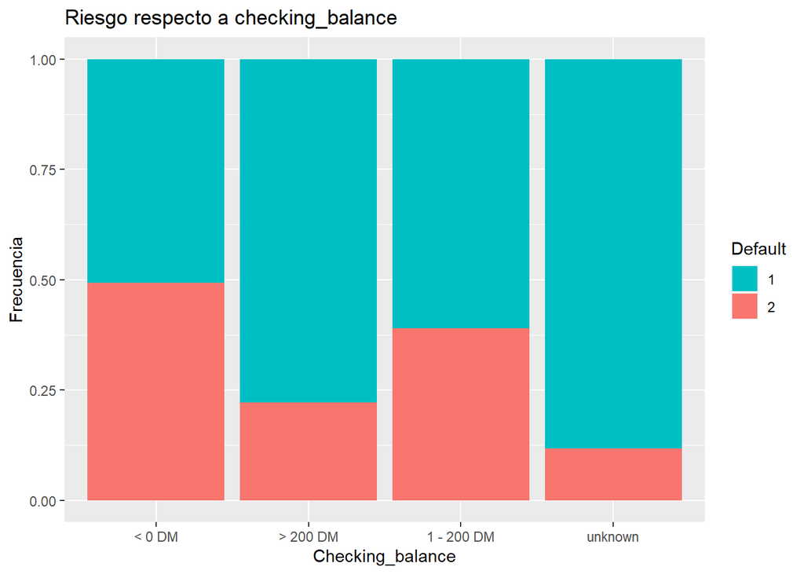

```r
# Gráfico
ggplot(data = df_copy, aes(x=checking_balance,fill=as.factor(default))) + geom_bar(position = "fill") +
  xlab("Checking_balance") +
  ylab("Frecuencia") +
  scale_fill_manual(name = "Default", values=c("#00bfc4","#f8766d")) +
  ggtitle("Riesgo respecto a checking_balance")
```

```r
# Tabla de contingencias
tabla_frec_abs <- table(df_copy$checking_balance, df_copy$default)
colnames(tabla_frec_abs) = c("No riesgo", "Sí riesgo")
tabla_frec_abs
```

```
##
##              No riesgo Sí riesgo
##   < 0 DM           139       135
##   > 200 DM          49        14
##   1 - 200 DM       164       105
##   unknown          348        46
```

```r
prop.table(tabla_frec_abs, margin = 1)
```

```
##
##              No riesgo Sí riesgo
##   < 0 DM     0.5072993 0.4927007
##   > 200 DM   0.7777778 0.2222222
##   1 - 200 DM 0.6096654 0.3903346
##   unknown    0.8832487 0.1167513
```

De las dos anteriores ejecuciones vemos que respecto al balance, es prácticamente igual de probable que si tienes un balance de gastos negativo el riesgo de concer del préstamo sea igual, ya que no riesgo es un 51% y riesgo un 49%. Por otro lado, si tenemos un balance > 200 DM o entre 1-200 DM es más probable que no haya riesgo a que haya, con unos porcentajes de no riesgo 0.78 y 0.61 y de riesgo de 0.22 y 0.39 respectivamente.

Continuamos el análisis respecto a los meses que dura el préstamo:

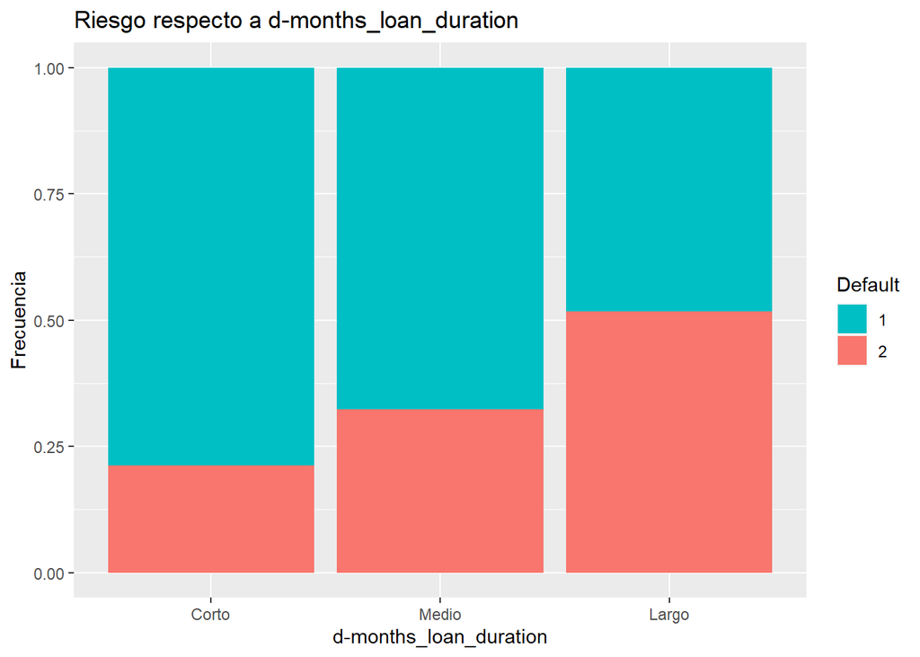

```r
# Gráfico
ggplot(data = df_copy, aes(x=`d-months_loan_duration`,fill=as.factor(default))) + geom_bar(position = "fill") +
  xlab("d-months_loan_duration") +
  ylab("Frecuencia") +
  scale_fill_manual(name = "Default", values=c("#00bfc4","#f8766d")) +
  ggtitle("Riesgo respecto a d-months_loan_duration")
```

```r
# Tabla de contingencias
tabla_frec_abs <- table(df_copy$`d-months_loan_duration`, df_copy$default)
colnames(tabla_frec_abs) = c("No riesgo", "Sí riesgo")
tabla_frec_abs
```

```
##
##         No riesgo Sí riesgo
##   Corto       283        76
##   Medio       375       179
##   Largo        42        45
```

```r
prop.table(tabla_frec_abs, margin = 1)
```

```
##
##         No riesgo Sí riesgo
##   Corto 0.7883008 0.2116992
##   Medio 0.6768953 0.3231047
##   Largo 0.4827586 0.5172414
```

Observamos que a medida que el periodo aumenta el riesgo también, por lo que intuimos que estas dos variables están muy correlacionadas positivamente. Cabe destacar que cuando el periodo del préstamo es largo el riesgo de conceder el préstamo es mayor, para ser más exactos cuando el préstamos dura más tenemos un riesgo del 52%.

Realizamos el análisis según el credit_history:

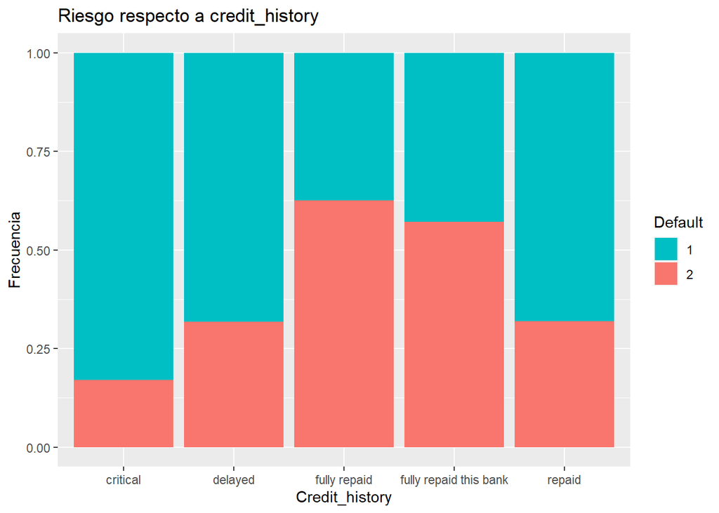

```r
# Gráfico
ggplot(data = df_copy, aes(x=credit_history,fill=as.factor(default))) + geom_bar(position = "fill") +
  xlab("Credit_history") +
  ylab("Frecuencia") +
  scale_fill_manual(name = "Default", values=c("#00bfc4","#f8766d")) +
  ggtitle("Riesgo respecto a credit_history")
```

```r
# Tabla de contingencias
tabla_frec_abs <- table(df_copy$credit_history, df_copy$default)
colnames(tabla_frec_abs) = c("No riesgo", "Sí riesgo")
tabla_frec_abs
```

```
##
##                          No riesgo Sí riesgo
##   critical                     243        50
##   delayed                       60        28
##   fully repaid                  15        25
##   fully repaid this bank        21        28
##   repaid                       361       169
```

```r
prop.table(tabla_frec_abs, margin = 1)
```

```
##
##                          No riesgo Sí riesgo
##   critical               0.8293515 0.1706485
##   delayed                0.6818182 0.3181818
##   fully repaid           0.3750000 0.6250000
##   fully repaid this bank 0.4285714 0.5714286
##   repaid                 0.6811321 0.3188679
```

Es curioso ver que cuando más riesgo tenemos de que no nos concedan un préstamos es cuando está completamente pagado, ya que el porcentaje de riesgo tanto en fully repaid como fully repaid this bank es de 63% y 57% respectivamente. En internet no encontramos nada sobre qué significa dichos niveles, ya que a apriori pensaba que si algo está completamente pagado es mejor, pero parace ser que no, que esto implica un mayor riesgo.

Analizamos el propósito del préstamo:

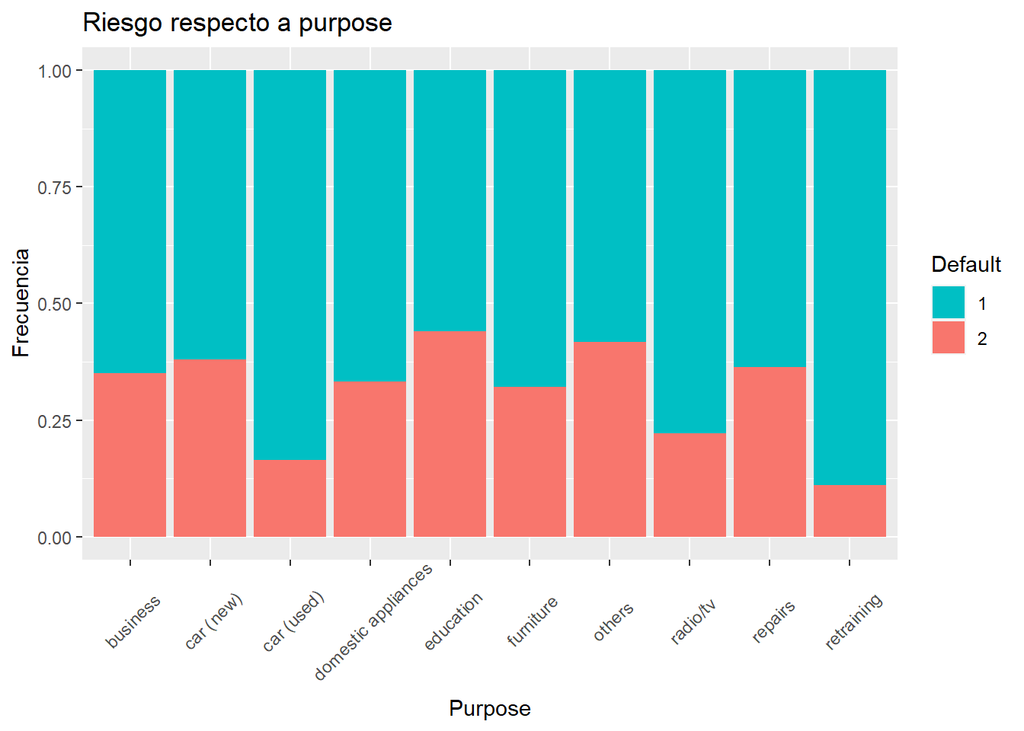

```r
# Gráfico
ggplot(data = df_copy, aes(x=purpose,fill=as.factor(default))) + geom_bar(position = "fill") +
  xlab("Purpose") +
  ylab("Frecuencia") +
  scale_fill_manual(name = "Default", values=c("#00bfc4","#f8766d")) +
  ggtitle("Riesgo respecto a purpose") +
  theme(axis.text.x = element_text(angle = 45, vjust = 0.6))
```

```r
# Tabla de contingencias
tabla_frec_abs <- table(df_copy$purpose, df_copy$default)
colnames(tabla_frec_abs) = c("No riesgo", "Sí riesgo")
tabla_frec_abs
```

```
##
##                       No riesgo Sí riesgo
##   business                   63        34
##   car (new)                 145        89
##   car (used)                 86        17
##   domestic appliances         8         4
##   education                  28        22
##   furniture                 123        58
##   others                      7         5
##   radio/tv                  218        62
##   repairs                    14         8
##   retraining                  8         1
```

```r
prop.table(tabla_frec_abs, margin = 1)
```

```
##
##                       No riesgo Sí riesgo
##   business            0.6494845 0.3505155
##   car (new)           0.6196581 0.3803419
##   car (used)          0.8349515 0.1650485
##   domestic appliances 0.6666667 0.3333333
##   education           0.5600000 0.4400000
##   furniture           0.6795580 0.3204420
##   others              0.5833333 0.4166667
##   radio/tv            0.7785714 0.2214286
##   repairs             0.6363636 0.3636364
##   retraining          0.8888889 0.1111111
```

Vemos que por norma general no suele haber mucho riesgo dependiendo del propósito del préstamo, pero es verdad que si buscamos un préstamo para estudiar hay un riesgo un poco elevado de un 44%, es decir, tenemos 22 registros de este tipo de propósito que se consideran como riesgo.

Analizamos la cantidad del préstamo:

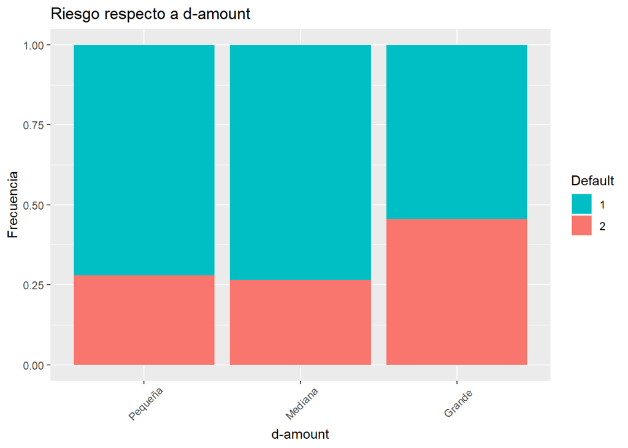

```r
# Gráfico
ggplot(data = df_copy, aes(x=`d-amount`,fill=as.factor(default))) + geom_bar(position = "fill") +
  xlab("d-amount") +
  ylab("Frecuencia") +
  scale_fill_manual(name = "Default", values=c("#00bfc4","#f8766d")) +
  ggtitle("Riesgo respecto a d-amount") +
  theme(axis.text.x = element_text(angle = 45, vjust = 0.6))
```

```r
# Tabla de contingencias
tabla_frec_abs <- table(df_copy$`d-amount`, df_copy$default)
colnames(tabla_frec_abs) = c("No riesgo", "Sí riesgo")
tabla_frec_abs
```

```
##
##           No riesgo Sí riesgo
##   Pequeña       311       121
##   Mediana       308       111
##   Grande         81        68
```

```r
prop.table(tabla_frec_abs, margin = 1)
```

```
##
##           No riesgo Sí riesgo
##   Pequeña 0.7199074 0.2800926
##   Mediana 0.7350835 0.2649165
##   Grande  0.5436242 0.4563758
```

En este caso vemos que a medida que aumenta la cantidad no implica que el riesgo sea mayor, ya que por ejemplo hay más riesgo cuando la cantidad es pequeña un 28% que cuando es mediana un 26%. Sin embago, si el préstamo solicitado es de cantidades elevadas el riesgo es mucho mayor, tanto que es casi un 46%.

Analizamos la variable savings_balance o balance de ahorros:

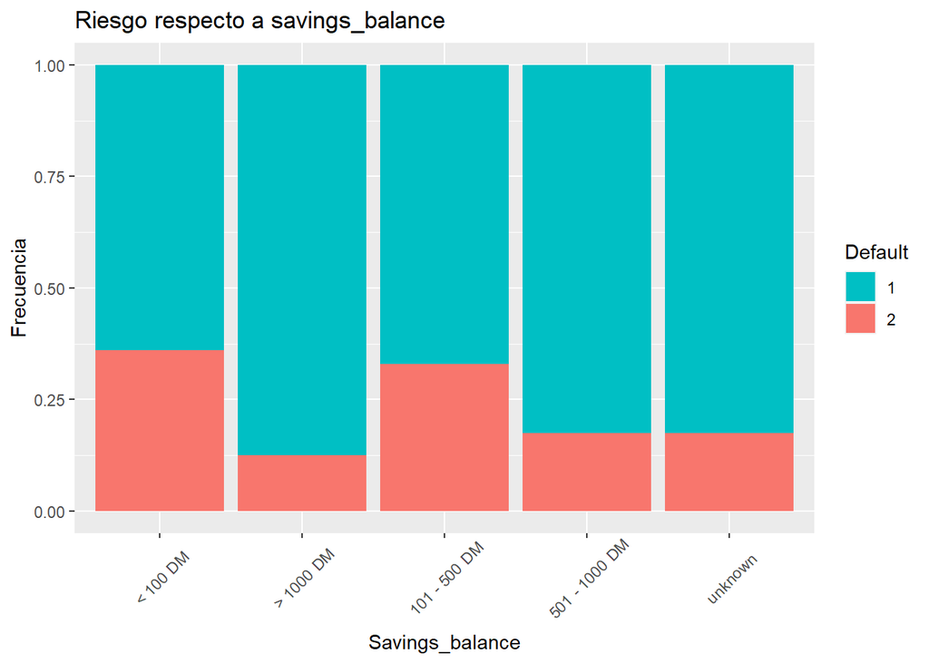

```r
# Gráfico
ggplot(data = df_copy, aes(x=savings_balance,fill=as.factor(default))) + geom_bar(position = "fill") +
  xlab("Savings_balance") +
  ylab("Frecuencia") +
  scale_fill_manual(name = "Default", values=c("#00bfc4","#f8766d")) +
  ggtitle("Riesgo respecto a savings_balance") +
  theme(axis.text.x = element_text(angle = 45, vjust = 0.6))
```

```r
# Tabla de contingencias
tabla_frec_abs <- table(df_copy$savings_balance, df_copy$default)
colnames(tabla_frec_abs) = c("No riesgo", "Sí riesgo")
tabla_frec_abs
```

```
##
##                 No riesgo Sí riesgo
##   < 100 DM            386       217
##   > 1000 DM            42         6
##   101 - 500 DM         69        34
##   501 - 1000 DM        52        11
##   unknown             151        32
```

```r
prop.table(tabla_frec_abs, margin = 1)
```

```
##
##                 No riesgo Sí riesgo
##   < 100 DM      0.6401327 0.3598673
##   > 1000 DM     0.8750000 0.1250000
##   101 - 500 DM  0.6699029 0.3300971
##   501 - 1000 DM 0.8253968 0.1746032
##   unknown       0.8251366 0.1748634
```

Otro de los condicionantes a que no nos concedan el préstamos es si tenemos pocos ahorros < 100 DM o si nuestros ahorros están entre 101 y 500 DM, en ambos casos tenemos un riesgo de 36% y 33% respectivamente.

Analizamos el tiempo que llevan trabajando los clientes y si esto supone un riesgo o no:

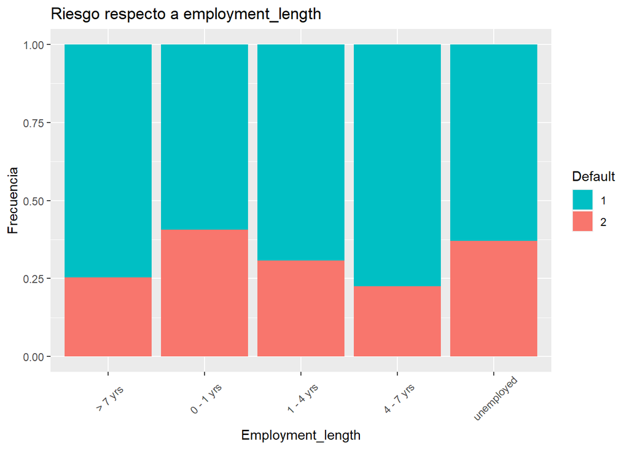

```r
# Gráfico
ggplot(data = df_copy, aes(x=employment_length,fill=as.factor(default))) + geom_bar(position = "fill") +
  xlab("Employment_length") +
  ylab("Frecuencia") +
  scale_fill_manual(name = "Default", values=c("#00bfc4","#f8766d")) +
  ggtitle("Riesgo respecto a employment_length") +
  theme(axis.text.x = element_text(angle = 45, vjust = 0.6))
```

```r
# Tabla de contingencias
tabla_frec_abs <- table(df_copy$employment_length, df_copy$default)
colnames(tabla_frec_abs) = c("No riesgo", "Sí riesgo")
tabla_frec_abs
```

```
##
##              No riesgo Sí riesgo
##   > 7 yrs          189        64
##   0 - 1 yrs        102        70
##   1 - 4 yrs        235       104
##   4 - 7 yrs        135        39
##   unemployed        39        23
```

```r
prop.table(tabla_frec_abs, margin = 1)
```

```
##
##              No riesgo Sí riesgo
##   > 7 yrs    0.7470356 0.2529644
##   0 - 1 yrs  0.5930233 0.4069767
##   1 - 4 yrs  0.6932153 0.3067847
##   4 - 7 yrs  0.7758621 0.2241379
##   unemployed 0.6290323 0.3709677
```

Comprobamos si el estado civil influye en el riesgo:

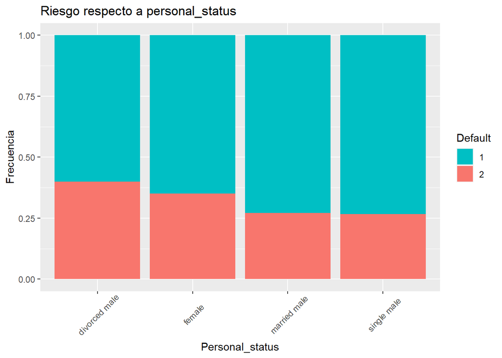

```r
# Gráfico
ggplot(data = df_copy, aes(x=personal_status,fill=as.factor(default))) + geom_bar(position = "fill") +
  xlab("Personal_status") +
  ylab("Frecuencia") +
  scale_fill_manual(name = "Default", values=c("#00bfc4","#f8766d")) +
  ggtitle("Riesgo respecto a personal_status") +
  theme(axis.text.x = element_text(angle = 45, vjust = 0.6))
```

```r
# Tabla de contingencias
tabla_frec_abs <- table(df_copy$personal_status, df_copy$default)
colnames(tabla_frec_abs) = c("No riesgo", "Sí riesgo")
tabla_frec_abs
```

```
##
##                 No riesgo Sí riesgo
##   divorced male        30        20
##   female              201       109
##   married male         67        25
##   single male         402       146
```

```r
prop.table(tabla_frec_abs, margin = 1)
```

```
##
##                 No riesgo Sí riesgo
##   divorced male 0.6000000 0.4000000
##   female        0.6483871 0.3516129
##   married male  0.7282609 0.2717391
##   single male   0.7335766 0.2664234
```

Vemos que no hay una clara relación entre el estado civil y el riesgo ya que más o menos todos los estados civiles tienen un riesgo más o menos parecido, salvando la distancia con los hombre divorciados, ya que éstos son los que tienen mayor riesgo de que no se les conceda un préstamo con un 40%.

Analizamos la edad y si influye en el riesgo:

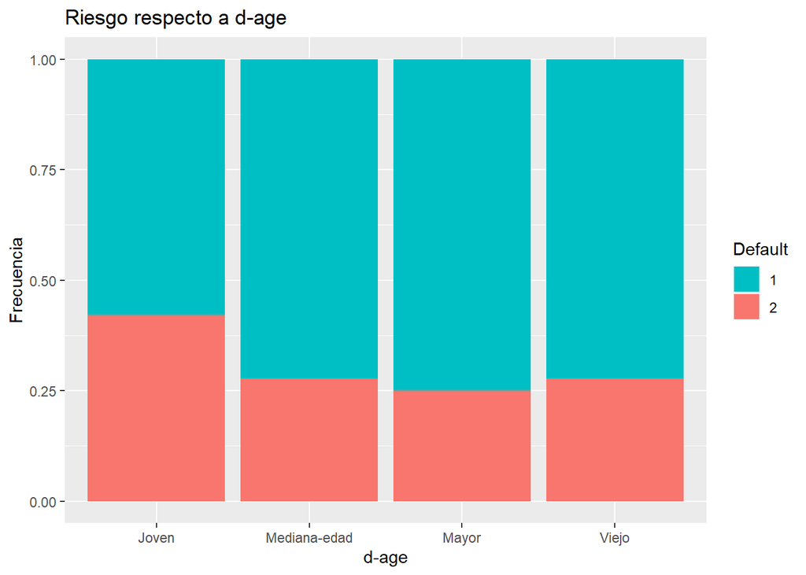

```r
# Gráfico
ggplot(data = df_copy, aes(x=`d-age`,fill=as.factor(default))) + geom_bar(position = "fill") +
  xlab("d-age") +
  ylab("Frecuencia") +
  scale_fill_manual(name = "Default", values=c("#00bfc4","#f8766d")) +
  ggtitle("Riesgo respecto a d-age")
```

```r
# Tabla de contingencias
tabla_frec_abs <- table(df_copy$`d-age`, df_copy$default)
colnames(tabla_frec_abs) = c("No riesgo", "Sí riesgo")
tabla_frec_abs
```

```
##
##                No riesgo Sí riesgo
##   Joven              110        80
##   Mediana-edad       451       173
##   Mayor              126        42
##   Viejo               13         5
```

```r
prop.table(tabla_frec_abs, margin = 1)
```

```
##
##                No riesgo Sí riesgo
##   Joven        0.5789474 0.4210526
##   Mediana-edad 0.7227564 0.2772436
##   Mayor        0.7500000 0.2500000
##   Viejo        0.7222222 0.2777778
```

Vemos que como es lógico, cuanto más joven eres más riesgo tiene de que no te concedan un préstamo, a esas edad apenas tienen una situación estable económica. Cabe destascar que a medida que aumenta la edad el riesgo no diminuye, ya que aunque los mayores tienen menos riesgo sobre los de mediana-edad, son los viejos los que tienen un mayor riesgo con un 27%.

Analizamos si el tipo de vivienda afecta al riesgo:

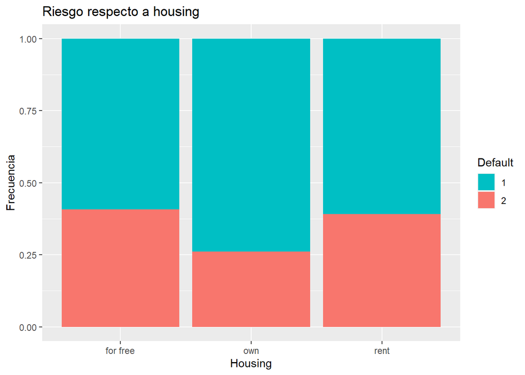

```r
# Gráfico
ggplot(data = df_copy, aes(x=housing,fill=as.factor(default))) + geom_bar(position = "fill") +
  xlab("Housing") +
  ylab("Frecuencia") +
  scale_fill_manual(name = "Default", values=c("#00bfc4","#f8766d")) +
  ggtitle("Riesgo respecto a housing")
```

```r
# Tabla de contingencias
tabla_frec_abs <- table(df_copy$housing, df_copy$default)
colnames(tabla_frec_abs) = c("No riesgo", "Sí riesgo")
tabla_frec_abs
```

```
##
##            No riesgo Sí riesgo
##   for free        64        44
##   own            527       186
##   rent           109        70
```

```r
prop.table(tabla_frec_abs, margin = 1)
```

```
##
##            No riesgo Sí riesgo
##   for free 0.5925926 0.4074074
##   own      0.7391304 0.2608696
##   rent     0.6089385 0.3910615
```